```python
import pandas as pd

# Data for Short Story 1
story1_controlled = [31.5, 31, 33.5, 21, 30.5, 28, 21, 32.5, 20, 21.5, 30, 26.5, 20, 26, 24]
story1_experimental = [39, 39, 41.5, 42.5, 37, 40, 37, 35.5, 44, 40, 42, 37, 43, 37, 40.5]

# Data for Short Story 2
story2_controlled = [32, 22, 22.5, 31, 29.5, 26, 32.5, 28.5, 22, 23, 25, 22.5, 25, 23.5, 26]
story2_experimental = [37, 34.5, 39.5, 34, 33, 34.5, 33, 39, 40.5, 39, 39.5, 45, 42, 40, 40.5]

# Create DataFrames
df_story1 = pd.DataFrame({
    'Controlled Group': story1_controlled,
    'Experimental Group': story1_experimental
})

df_story2 = pd.DataFrame({
    'Controlled Group': story2_controlled,
    'Experimental Group': story2_experimental
})

# Print the DataFrames
print("DataFrame for Short Story 1:")
print(df_story1)

print("\nDataFrame for Short Story 2:")
print(df_story2)
```

```
DataFrame for Short Story 1:
    Controlled Group  Experimental Group
0               31.5                39.0
1               31.0                39.0
2               33.5                41.5
3               21.0                42.5
4               30.5                37.0
5               28.0                40.0
6               21.0                37.0
7               32.5                35.5
8               20.0                44.0
9               21.5                40.0
10              30.0                42.0
11              26.5                37.0
12              20.0                43.0
```

[output cut: 20 more lines]

```python
controlled_group = (df_story1['Controlled Group'] + df_story2['Controlled Group']) / 2

# Calculate mean value for each index in Short Story 2
experimental_group = (df_story1['Experimental Group'] + df_story2['Experimental Group']) / 2

# Print the mean values
print("Mean value for each index in Short Story 1:")
print(controlled_group)

print("\nMean value for each index in Short Story 2:")
print(experiment_group)
```

```
Mean value for each index in Short Story 1:
0     31.75
1     26.50
2     28.00
3     26.00
4     30.00
5     27.00
6     26.75
7     30.50
8     21.00
9     22.25
10    27.50
11    24.50
12    22.50
13    24.75
```

[output cut: 20 more lines]

```python
from scipy import stats


# Perform Shapiro-Wilk test for normality
shapiro_stat_controlled, shapiro_p_controlled = stats.shapiro(controlled_group)
shapiro_stat_experimental, shapiro_p_experimental = stats.shapiro(experimental_group)

# Print the results
print("Controlled Group Shapiro-Wilk test:")
print("Statistic:", shapiro_stat_controlled, "p-value:", shapiro_p_controlled)
print("Experimental Group Shapiro-Wilk test:")
print("Statistic:", shapiro_stat_experimental, "p-value:", shapiro_p_experimental)
```

```
Controlled Group Shapiro-Wilk test:
Statistic: 0.9765563607215881 p-value: 0.9405418634414673
Experimental Group Shapiro-Wilk test:
Statistic: 0.9520710706710815 p-value: 0.5576421022415161
```

For the controlled group, the Shapiro-Wilk test statistic is approximately 0.9766 and the p-value is approximately 0.9405. For the experimental group, the Shapiro-Wilk test statistic is approximately 0.9521 and the p-value is approximately 0.5576. For both groups, the p-values are greater than the typical significance level of 0.05. This suggests that we do not have sufficient evidence to reject the null hypothesis of normality. Therefore, we can assume that the data for both groups are approximately normally distributed.

# Check Normal distribution in both group

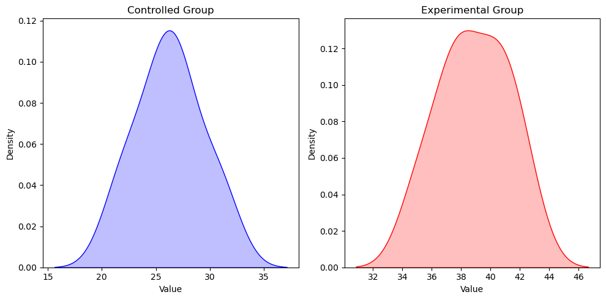

```python
import seaborn as sns
import matplotlib.pyplot as plt

# Create density plots
plt.figure(figsize=(10, 5))

plt.subplot(1, 2, 1)
sns.kdeplot(controlled_group, color='blue', shade=True)
plt.title('Controlled Group')
plt.xlabel('Value')
plt.ylabel('Density')

plt.subplot(1, 2, 2)
sns.kdeplot(experimental_group, color='red', shade=True)
plt.title('Experimental Group')
plt.xlabel('Value')
plt.ylabel('Density')

plt.tight_layout()
plt.show()
```

```python
from scipy import stats


# Perform t-test
t_statistic, p_value = stats.ttest_ind(controlled_group, experimental_group)

# Print the results
print("T-statistic:", t_statistic)
print("P-value:", p_value)

# Determine significance
alpha = 0.05
if p_value < alpha:
    print("The difference between the groups is statistically significant (reject the null hypothesis)")
else:
    print("There is no statistically significant difference between the groups (fail to reject the null hypothesis)")
```

```
T-statistic: -12.546591508815505
P-value: 5.171455465021041e-13
The difference between the groups is statistically significant (reject the null hypothesis)
```

Null Hypothesis:

Given that the p-value is much smaller than the typical significance level of 0.05, we reject the null hypothesis. This means that there is strong evidence to suggest that there is a statistically significant difference between the means of the controlled and experimental groups.

In other words, the data provides sufficient evidence to conclude that the difference in means is unlikely to have occurred by random chance alone. Therefore, we can infer that there is a genuine difference between the two groups.